# Week_5 Day_2 Homework_mahri

## Introduction to ggplot2 homework

**Question 1.** Load in the libraries you need, and look at the backpack data. Take note of variable names and dimensions.

```r
library(tidyverse)
library(ggthemes)
```

```r
backpack <- CodeClanData::backpack
backpack
```

| backpack_weight | body_weight | ratio | back_problems | major | year | sex | status | units |
| --- | --- | --- | --- | --- | --- | --- | --- | --- |
| 9 | 125 | 0.0720000 | 1 | Bio | 3 | Female | U | 13 |
| 8 | 195 | 0.0410256 | 0 | Philosophy | 5 | Male | U | 12 |
| 10 | 120 | 0.0833333 | 1 | GRC | 4 | Female | U | 14 |
| 6 | 155 | 0.0387097 | 0 | CSC | 6 | Male | G | 0 |
| 8 | 180 | 0.0444444 | 0 | EE | 2 | Female | U | 14 |
| 5 | 240 | 0.0208333 | 0 | History | 0 | Male | G | 0 |
| 8 | 170 | 0.0470588 | 0 | CM | 3 | Male | U | 15 |
| 4 | 185 | 0.0216216 | 1 | ARCE | 5 | Female | U | 18 |
| 5 | 130 | 0.0384615 | 0 | Bio | 4 | Female | U | 14 |
| 2 | 120 | 0.0166667 | 0 | Bio | 5 | Female | U | 8 |

[output cut: 90 more lines]

```r
dim(backpack)
```

```
[1] 100   9
```

```r
glimpse(backpack)
```

```
Rows: 100
Columns: 9
$ backpack_weight <int> 9, 8, 10, 6, 8, 5, 8, 4, 5, 2, 8, 21, 11, 11, 12, 11, 13, 6, 10, 5, 20, 14, 1~
$ body_weight     <int> 125, 195, 120, 155, 180, 240, 170, 185, 130, 120, 135, 160, 170, 170, 125, 17~
$ ratio           <dbl> 0.0720000, 0.0410256, 0.0833333, 0.0387097, 0.0444444, 0.0208333, 0.0470588, ~
$ back_problems   <int> 1, 0, 1, 0, 0, 0, 0, 1, 0, 0, 0, 0, 0, 1, 1, 0, 1, 0, 1, 0, 0, 1, 0, 0, 0, 1,~
$ major           <fct> Bio, Philosophy, GRC, CSC, EE, History, CM, ARCE, Bio, Bio, Bus, ME, CPE, CPE~
$ year            <int> 3, 5, 4, 6, 2, 0, 3, 5, 4, 5, 3, 5, 4, 4, 3, 4, 4, 3, 3, 3, 2, 2, 5, 5, 3, 1,~
$ sex             <fct> Female, Male, Female, Male, Female, Male, Male, Female, Female, Female, Femal~
$ status          <fct> U, U, U, G, U, G, U, U, U, U, U, U, U, U, U, U, U, U, U, U, U, U, U, U, U, U,~
$ units           <int> 13, 12, 14, 0, 14, 0, 15, 18, 14, 8, 15, 12, 16, 16, 12, 16, 16, 16, 17, 14, ~
```

```r
names(backpack)
```

```
[1] "backpack_weight" "body_weight"     "ratio"           "back_problems"   "major"
[6] "year"            "sex"             "status"          "units"
```

The dataset “backpack” has 100 rows and 9 columns with column names:

- backpack_weight - ranging from 2 - 35
- body_weight - ranging from 105 - 270 (probably lbs)
- ratio - backpack weight divided by body weight
- back_problems - a numeric column where 0 = “no back problems” and 1 = “back problems”
- major - the individual’s University Major
- year - ranging from 0 - 6
- sex - “male” or “female”
- status - “U” or “G”
- units - ranging from 0 - 20

**Question 2.** What is the distribution of backpack weights that students are carrying? Choose an appropriate graph to show the distribution.

**Answer** There is one outlying student carrying a 35kg bag (I would hope that the weight of backpacks is not measured in kg’s or that this was a mistake). Most of the students are carring bags of between 5 and 15kgs with the lightest bag weighing 2kg.

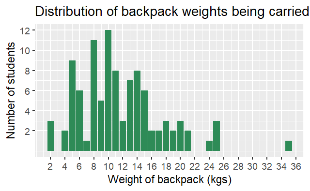

```r
backpack_weights <- backpack %>%
  group_by(backpack_weight) %>%
  summarise(count = n())

ggplot(backpack_weights) +
  aes(x = backpack_weight, y = count) +
  geom_col(fill = "seagreen") +
  scale_x_continuous(breaks = seq(2, 36, 2)) +
  scale_y_continuous(breaks = seq(2, 14, 2)) +
  labs(x = "Weight of backpack (kgs)",
       y = "Number of students",
       title = "Distribution of backpack weights being carried by students")
```

**Question 3.** Are there differences in backpack weight between sex?

**Answer**

oops, I couldn’t work out the class answer below (my answer below the class answer)

```r
# CLASS ANSWER women or men carrying heavier backpacks?
ggplot(backpack) +
  aes(x = backpack_weight, fill = sex) +
  scale_fill_manual(values=c('#E69F00', '#56B4E9')) +
  geom_histogram(bins = 20, col = "white", show.legend = FALSE) +
  theme_light() +
  labs(y = "number of backpacks", x = "weight") +
  facet_wrap(~ sex, nrow = 2)
```

Keeping in mind that there are 10 more females (n = 55) than males (n = 45), the total sum of backpack weights for females is higher than males: 607kg and 559kg respectfully. The average weight for female’s bags is 11kg, whereas male’s bags are 12kg on average. We therefore do not see a great difference in bag weight between genders.

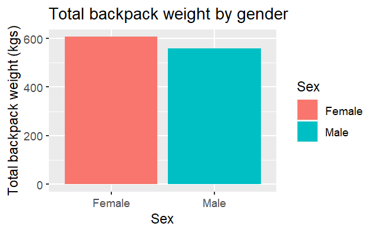

**Question 4.** What is the relationship between body weight and backpack weight?

**Answer** From looking at the scatter plot, there does not appear to be a very clear relationship between body weight and backback weight. However, there might be a slight argument for an increase in one relating to an increase in the other which could be checked with statistical tests.

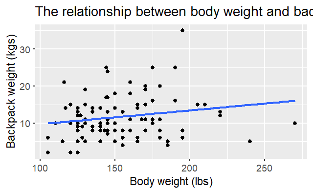

```r
ggplot(backpack)+
  aes(x = body_weight, y = backpack_weight) +
  geom_point() +
  geom_smooth(method = "lm", se = FALSE) +
  labs(x = "Body weight (lbs)",
       y = "Backpack weight (kgs)",
       title = "The relationship between body weight and backpack weight")
```

**Question 5.** Is this relationship different between men and women? Choose an appropriate plot and interpret your findings.

**Answer** I would not argue that the relationship between body weight and backpack weight is different between sexes though men generally weigh more. Again however, there might be a slight argument for an increase in one relating to an increase in the other which could be checked with statistical tests.

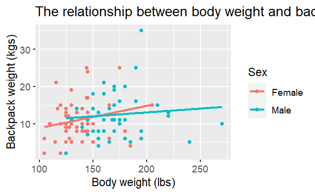

```r
ggplot(backpack)+
  aes(x = body_weight, y = backpack_weight, colour = sex) +
  geom_point() +
  geom_smooth(method = "lm", se = FALSE)+
  labs(x = "Body weight (lbs)",
       y = "Backpack weight (kgs)",
       colour = "Sex",
       title = "The relationship between body weight and backpack weight")
```

CLASS ANSWER

```r
# different for males vs females?
ggplot(backpack) +
  aes(x = body_weight, y = backpack_weight, color = sex) +
  geom_point() +
  facet_wrap(~sex) +
    scale_color_manual(values=c('#E69F00', '#56B4E9'))+
    labs(x = "body weight", y = "backpack weight")
```

**Question 6.** What proportion of students report back pain?

**Answer** Just less than 1/3 of students (32%) report to have back problems and slightly over 2/3 (68%) of students do not report back problems.

```r
backpack %>%
  group_by(back_problems) %>%
  summarise(count = n()) %>%
  mutate(frequencey = formattable::percent(count / sum(count)))
```

| back_problems | count | frequencey |
| --- | --- | --- |
| 0 | 68 | 68.00% |
| 1 | 32 | 32.00% |

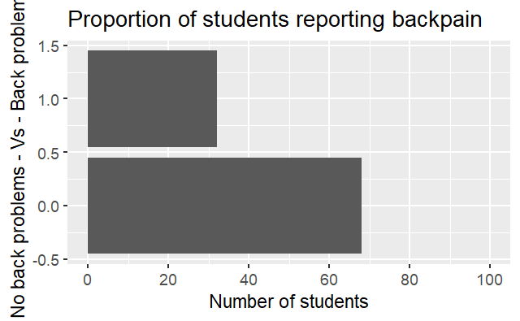

```r
# 32% of students report back problems, 68% do not.


backpain <- ggplot(backpack) +
  aes(x = back_problems) + # fill = back_problems - didn't work
  geom_bar() +
  coord_flip() +
  scale_y_continuous(breaks = seq(0, 100, 20),
                     limits = c(0, 100)) +
  scale_fill_manual(values = c("coral", "seagreen"), # this didn't work
                   name = "",
                   labels = c("No back pain", "Back pain")) +
  labs(x = "No back problems - Vs - Back problems",
       y = "Number of students",
       title = "Proportion of students reporting backpain")
backpain
```

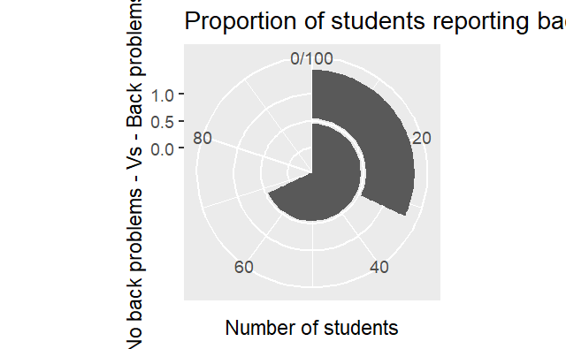

```r
# ^ This is ugly
# Note that filling with colour didn't work... I need to change the 0 and 1 to
# "No problems" and "Problems" as well.


# Just practicing... this outcome was not what I was hoping for:
pie <- backpain + coord_polar("y", start = 0) +
  scale_fill_brewer(palette = "Dark2")
pie
```

ANSWER FROM CLASS

```r
# convert backpain to factor and create labelled column
backpack <- backpack %>%
  mutate(backpain_labelled = recode(back_problems,
                       "0" = "No",
                       "1" = "Yes"))

ggplot(backpack) +
  aes(x = backpain_labelled, fill = backpain_labelled) +
  geom_bar() +
ylim(0,100) +
  labs(x = "backpain reported", y = "student count") +
    scale_fill_manual(values=c('#f0ca41', '#5022bd'))+
theme(legend.position = "none")
```

**Question 7.** Is this proportion different between men and women?

**Answer** Yes. Women have much closer results with 44% (n = 24) reporting back problems and 56% (n = 31) reporting no pain. Only 18% (n = 8) of men reported back problems with 82% (n = 37) of men reporting to have none.

(Not happy with this chart especially as I still need to change the backpain values)

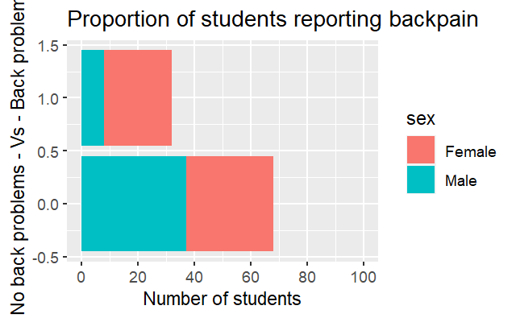

CLASS ANSWER

```r
# is it different for males and females?
ggplot(backpack) +
  aes(x = backpain_labelled, fill = backpain_labelled) +
  geom_bar() +
  labs(x = "backpain reported", y = "student count") +
  facet_wrap(~sex) +
      scale_fill_manual(values=c('#f0ca41', '#5022bd'))+
theme(legend.position = "none")

#Interesting… more females report it than males. Perhaps something to do with them weighing less but carrying similarly heavy backpacks?
```

**Question 8.** Now you’ve investigated your data separately, create plots to describe the relationship between backpack weight, body weight, gender and reported backpain.

Try both backpack_weight and body_weight as well as the ratio.

Hint: faceting would be useful here.

**Answer** (I really am not sure what to do with the ratio here)

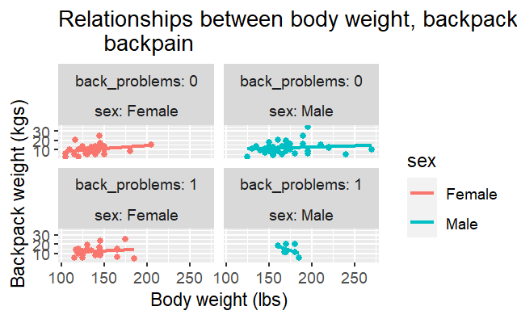

```r
ggplot(backpack) +
  aes(x = body_weight, y = backpack_weight, group = sex, colour = sex) +
  geom_point(show.legend = FALSE) +
  geom_smooth(method = "lm", se = FALSE)+
  facet_wrap(back_problems~sex, labeller = "label_both") +
  labs(x = "Body weight (lbs)",
       y = "Backpack weight (kgs)",
       title = "Relationships between body weight, backpack weight, gender, and
       backpain" )
```

CLASS ANSWER QUESTION 8

```r
# make the labels nice
pain_labels <- c("backpain: no", "backpain: yes")
names(pain_labels) <- c("No", "Yes")

sex_labels <- c("sex: female", "sex: male")
names(sex_labels) <- c("Female", "Male")


ggplot(backpack) +
  aes(x = body_weight, y = backpack_weight, color = backpain_labelled) +
  geom_point() +
  facet_grid(sex ~ backpain_labelled,
             labeller = labeller(backpain_labelled = pain_labels, sex = sex_labels)) +
  labs(x = "\n body weight", y = "backpack weight \n") +
      scale_color_manual(values=c('#f0ca41', '#5022bd'))+
theme(legend.position = "none")
```

“Seems there is a relationship between backpack weight, body weight, gender and reported backpain….

Could be weird, let’s plot the ratio to confirm…”

```r
ggplot(backpack) +
  geom_histogram(aes(x = ratio, fill = backpain_labelled), bins = 20, col = "white") +
  facet_grid(sex ~ backpain_labelled,
             labeller = labeller(backpain_labelled = pain_labels, sex = sex_labels)) +
  labs(x = "\n body weight: backpack weight ratio") +
      scale_fill_manual(values=c('#f0ca41', '#5022bd'))+
theme(legend.position = "none")
```

“Everything still seems to be the same. Women seem to be reporting more backpack than men.

Sum up: the main area of focus seems to be on the differences in reported backpain across the different biological sexes. That’s maybe an area to focus on. Plus, collect more data so we can do the analysis across majors and years more thoroughly.”